# Chapter 12 - Monsters and Mixtures

```r
suppressPackageStartupMessages(library(tidyverse))
suppressPackageStartupMessages(library(brms))
suppressPackageStartupMessages(library(tidybayes))
```

# Over dispersed outcomes

For count related processes, sometimes the outcome variable has more variance than expected even after conditioning on as much as we can. We can mitigate the effect of over-dispersion by using *continuous mixture* models which attach linear models to the distribution of observations.

## Beta-binomial

A beta-binomial model assumes that each binomial count observation has its own probability of success. The model estimates the distribution of probabilities of success across cases, instead of a single probability of success. And predictor variables change the shape of this distribution, instead of directly determining the probability of each success.

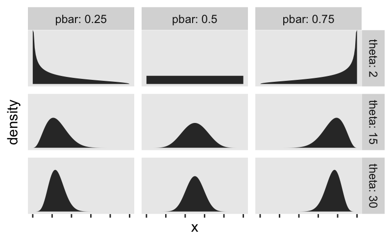

```r
crossing(
  pbar = c(.25, .5, .75),
  theta = c(2, 15, 30),
  x = seq(from = 0, to = 1, length.out = 100)) %>%
  mutate(
    density = rethinking::dbeta2(x, pbar, theta)) %>%
  ggplot(aes(x = x, y = density)) +
    geom_ribbon(aes(x = x,
                    ymin = 0,
                    ymax = density)) +
    facet_grid(theta ~ pbar,
               labeller = label_both) +
    theme(panel.grid = element_blank(),
          axis.ticks.y = element_blank(),
          axis.text = element_blank()) +
  scale_x_continuous(breaks = seq(from = 0, to = 1, by = .2))
```

In betabinomial models, we fit a linear model to the `pbar` parameter to govern the central tendency of the probability distribution by conditioning on covariates.

The admission data below is over-dispersed if we ignore department. This is because the departments vary a lot in baseline admission rates. We’ve already seen that ignoring this variation leads to an incorrect inference about applicant gender. Now let’s fit a beta-binomial model, ignoring department, and see how it picks up on the variation that arises from the omitted variable.

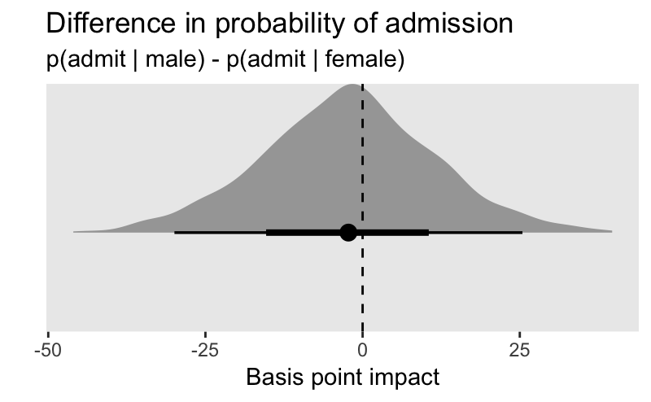

```r
suppressPackageStartupMessages(library(rethinking))
data(UCBadmit)
df <- as_data_frame(UCBadmit) %>%
  mutate(applicant_male = ifelse(applicant.gender == "male", 1, 0),
         applicant_female = applicant_male * -1 + 1)
rm(UCBadmit)


m12.1 <- ulam(
  alist(
    admit ~ dbetabinom(applications, pbar, theta),
    logit(pbar) <- a*applicant_male + b*applicant_female,
    c(a, b) ~ dnorm(0, 1.5),
    theta ~ dexp(1)
  ),
  data = list(
    admit = df$admit,
    applications = df$applications,
    applicant_male = as.integer(df$applicant_male),
    applicant_female = as.integer(df$applicant_female)),
  chains = 4)
extract.samples(m12.1) %>%
  as_data_frame %>%
  transmute(diff = inv_logit_scaled(a) - inv_logit_scaled(b)) %>%
  gather() %>%
  mutate(value = value * 100) %>%
  ggplot(aes(value, key)) +
    geom_halfeyeh() +
    geom_vline(xintercept = 0, linetype = 2) +
    ylab("") + xlab("Basis point impact") +
    ggtitle("Difference in probability of admission",
            "p(admit | male) - p(admit | female)") +
    theme(panel.grid = element_blank(),
          axis.ticks.y = element_blank(),
          axis.text.y = element_blank())
```

The beta-binomial model creates fixed effect for each row in the data - each combination of department and gender.

## Negative-binomial (Gamma-Poisson)

Here, we assume that each Poisson count observation has its own rateand estimates the shape of a gamma distribution to describe the POisson rates across cases. So basically, its the same as a beta-binomial model except that we use a gamma distribution of rates instead of a beta distribution of $p(succes)$’s.

Lets show this one more time with the UCB admit data.

```r
b12.3 <- brm(data = df, family = negbinomial,
             admit ~ 1 + applicant.gender,
             prior = c(prior(normal(0, 10), class = Intercept),
                       prior(normal(0, 1), class = b),
                       prior(gamma(0.01, 0.01), class = shape)),
    iter = 4000, warmup = 1000, cores = 2, chains = 2,
    refresh = 0)
```

```
recompiling to avoid crashing R session
```

```r
print(b12.3)
```

```
 Family: negbinomial
  Links: mu = log; shape = identity
Formula: admit ~ 1 + applicant.gender
   Data: df (Number of observations: 12)
Samples: 2 chains, each with iter = 4000; warmup = 1000; thin = 1;
         total post-warmup samples = 6000

Population-Level Effects:
                     Estimate Est.Error l-95% CI u-95% CI Eff.Sample Rhat
Intercept                4.69      0.40     3.97     5.52       3671 1.00
applicant.gendermale     0.59      0.50    -0.42     1.55       4332 1.00

Family Specific Parameters:
      Estimate Est.Error l-95% CI u-95% CI Eff.Sample Rhat
shape     1.22      0.47     0.50     2.32       3383 1.00

Samples were drawn using sampling(NUTS). For each parameter, Eff.Sample
is a crude measure of effective sample size, and Rhat is the potential
scale reduction factor on split chains (at convergence, Rhat = 1).
```

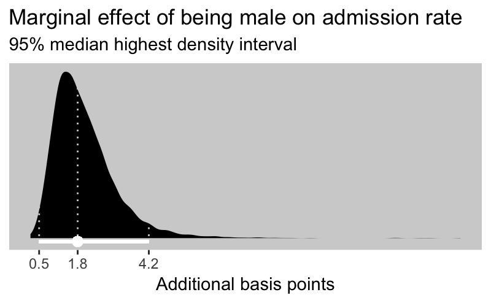

```r
post <- gather_draws(b12.3, b_applicant.gendermale) %>%
  mutate(.value = exp(.value))

male_marginal_effect <- post %>%
  median_hdi() %>%
  select(.lower, .upper, .value) %>%
  as.numeric() %>%
  round(1)

post %>%
  ggplot(aes(x = .value)) +
    geom_density(colour = "transparent", fill = "black") +
    scale_y_continuous(NULL, breaks = NULL) +
    geom_vline(xintercept = male_marginal_effect,
               colour = "grey82", linetype = 3) +
    geom_segment(aes(x = .5, xend = 4.2, y = 0, yend = 0), size = 1,
                 colour = "white", position = position_nudge(y=-.01)) +
    geom_point(aes(x = 1.8, y = 0), colour = "white", fill = "white",
               size = 2.5, position = position_nudge(y=-.01)) +
    scale_x_continuous(breaks = male_marginal_effect) +
    theme(panel.background = element_rect(fill = "grey82"),
          panel.grid = element_blank()) +
  ggtitle("Marginal effect of being male on admission rate",
          "95% median highest density interval") +
  xlab("Additional basis points")
```

```r
NA
```

# Zero inflated outcomes

Sometimes, the process creating your counts gets thrown off. For example, maybe your shoppers get drunk and don’t make purchases. Or maybe your manuscript writing monks get drunk and don’t produce manuscripts. To solve this problem, we create a *mixture* of two process, one that determines drinking vs. working, and one that determines manuscripts created given that they are working.
$$y_i \sim ZIPoisson(p_i, \lambda_i)
\\
logit(p_i) = \alpha_p + \beta_p x_i
\\
log(\lambda_i) = \alpha_\lambda + \beta_\lambda x_i$$
To show what we mean, lets start by simulating this process.

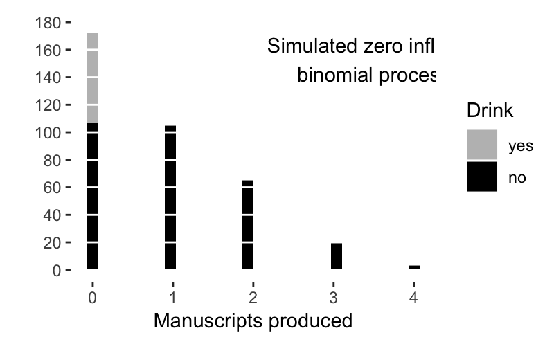

```r
# Assume monks will choose to drink 20% of days
p_drink <- .2
# Else they make 1 manuscript a day
rate_work <- 1
# Simulate for a year
N <- 365

df <- tibble(
  drink = rbinom(N, 1, p_drink),
  y = (1-drink) * rpois(N, rate_work)) %>%
  mutate(drink = ifelse(drink == 1, "yes", "no"),
         Drink = factor(drink, c("yes", "no")))

breaks <- seq(from = 0, to = 180, by = 20)

ggplot(df, aes(y, fill = Drink)) +
  geom_histogram(bins = 30) +
  geom_hline(yintercept = breaks, colour = "white") +
  scale_fill_manual(values = c("grey", "black")) +
  scale_y_continuous(breaks = breaks) +
  theme(panel.grid = element_blank(),
        panel.background = element_rect(fill = "white")) +
  annotate("text", label = "Simulated zero inflated \nbinomial process",
           x = 3.5, y = 153) +
  xlab("Manuscripts produced") + ylab("")
```

Now then, lets code this explicitly with the data and stan.

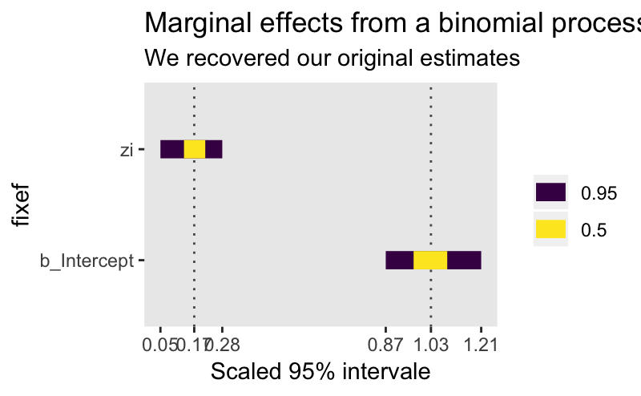

```r
b11.4 <-
  brm(data = df, family = zero_inflated_poisson,
      y ~ 1,
                # Rate of work
      prior = c(prior(normal(1, .5), class = Intercept),
                # Probability of drinking
                prior(normal(-1.5, 1), class = zi)),
      cores = 4, refresh = 0, sample_prior = "yes")

hdi <- spread_draws(b11.4, b_Intercept, zi) %>%
  mutate(b_Intercept = exp(b_Intercept)) %>%
  gather_variables %>%
  median_hdi(.width = c(.5, .95))

hdi %>%
  filter(.width == .95) %>%
  select(.value, .lower, .upper) %>%
  gather() %>%
  pull(value) %>%
  unique ->
  breaks

hdi %>%
  ggplot(aes(x = .value, y = .variable)) +
    geom_vline(xintercept = hdi$.value,
               linetype = 3, alpha = .7) +
    tidybayes::geom_intervalh() +
    theme(panel.grid = element_blank()) +
    scale_x_continuous(breaks = breaks,
                       labels = as.character(round(breaks, 2))) +
    ylab("fixef") + xlab("Scaled 95% intervale") +
    ggtitle("Marginal effects from a binomial process",
            "We recovered our original estimates")
```

# Ordered categorical outcomes

We can tackle these kinds of outcomes using a cumulative link function. By linking a linear model to cumulative probability, it is possible to guarantee the ordering of the outcomes.

We will use some survey data as an example where there are is an ordered logit responses of cardinality 7. We describe it below in sample.

```r
suppressPackageStartupMessages(library(rethinking))
data(Trolley)
df <- Trolley
rm(Trolley)
detach("package:rethinking")

df_response <- df %>%
  group_by(response) %>%
  summarise(freq = n()) %>%
  mutate(cumulative_sum = cumsum(freq),
         cumulative_proportion = cumulative_sum / sum(freq),
         logistic_cumulative_proportion = logit_scaled(cumulative_proportion))

print(df_response)
```

| response | freq | cumulative_sum | cumulative_proportion | logistic_cumulative_proportion |
| --- | --- | --- | --- | --- |
| 1 | 1274 | 1274 | 0.1282981 | -1.9160912 |
| 2 | 909 | 2183 | 0.2198389 | -1.2666056 |
| 3 | 1071 | 3254 | 0.3276939 | -0.7186340 |
| 4 | 2323 | 5577 | 0.5616314 | 0.2477857 |
| 5 | 1462 | 7039 | 0.7088620 | 0.8898637 |
| 6 | 1445 | 8484 | 0.8543807 | 1.7693809 |
| 7 | 1446 | 9930 | 1.0000000 | Inf |

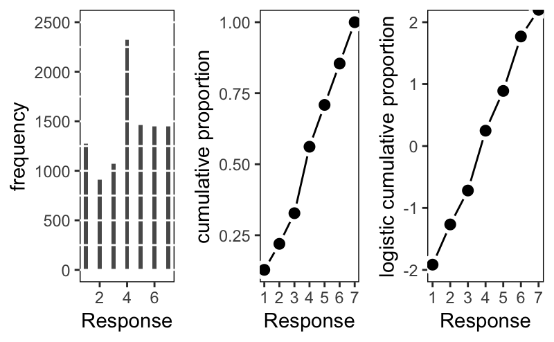

```r
p1 <- df_response %>%
  ggplot(aes(x=response, y = freq)) +
    geom_histogram(stat="identity", width=.3) +
    geom_hline(yintercept = seq(from=0, to=2500, by=250),
               colour = "white") +
    theme(panel.grid = element_blank(),
          panel.background = element_rect(colour = "black", fill = "white")) +
    xlab("Response") + ylab("frequency")

p2 <- df_response %>%
  ggplot(aes(x = response, y = cumulative_proportion)) +
    geom_line(colour = "black") +
    geom_point(shape = 21, colour = "white",
               size = 3, stroke = 1.5, fill = "black") +
  theme(panel.grid = element_blank(),
        panel.background = element_rect(colour = "black", fill = "white")) +
  scale_x_continuous(breaks = 1:7) +
  ylab("cumulative proportion") + xlab("Response")

p3 <- df_response %>%
  ggplot(aes(x = response, y = logistic_cumulative_proportion)) +
    geom_line(colour = "black") +
    geom_point(shape = 21, colour = "white",
               size = 3, stroke = 1.5, fill = "black") +
  theme(panel.grid = element_blank(),
        panel.background = element_rect(colour = "black", fill = "white")) +
  scale_x_continuous(breaks = 1:7) +
  coord_cartesian(ylim = c(-2, 2)) +
  ylab("logistic cumulative proportion") + xlab("Response")

gridExtra::grid.arrange(p1, p2, p3, ncol = 3)
```

Lets now try to redescribe the logistic cumulative proportions as a series of intercepts in a stan model. We summarize this in the equation below. Each intercept will equal the log odds of being less than or equal to reponse $k$.

$$\log \frac{Pr(y_i \leq k)}{1 - Pr(y_i \leq k)} = \alpha_k$$

We need to be able to use this to compute the likelihood of each possible response value. We can do this by subtracting out the marginal cumulative proportions.
$$p_k = Pr(y_i = k) = Pr(y_i \leq k) - Pr(y_i \leq k - 1)$$

Now that we’ve uncovered it, lets let BRMS take care of it under the hood for us.

```r
b11.1 <-
  brm(data = df, family = cumulative,
      response ~ 1,
      prior(normal(0, 10), class = Intercept),
      iter = 2000, warmup = 1000, cores = 2, chains = 2,
      refresh = 0, sample_prior = "yes")
summary(b11.1)
```

```
 Family: cumulative
  Links: mu = logit; disc = identity
Formula: response ~ 1
   Data: df (Number of observations: 9930)
Samples: 2 chains, each with iter = 2000; warmup = 1000; thin = 1;
         total post-warmup samples = 2000

Population-Level Effects:
             Estimate Est.Error l-95% CI u-95% CI Eff.Sample Rhat
Intercept[1]    -1.92      0.03    -1.98    -1.86       1286 1.00
Intercept[2]    -1.27      0.02    -1.31    -1.22       1908 1.00
Intercept[3]    -0.72      0.02    -0.76    -0.68       2313 1.00
Intercept[4]     0.25      0.02     0.21     0.29       2358 1.00
Intercept[5]     0.89      0.02     0.85     0.93       2252 1.00
Intercept[6]     1.77      0.03     1.71     1.83       2188 1.00

Samples were drawn using sampling(NUTS). For each parameter, Eff.Sample
is a crude measure of effective sample size, and Rhat is the potential
scale reduction factor on split chains (at convergence, Rhat = 1).
```

Notice that we regain the same estimates as before.

```r
tibble(
  fit = c(fixef(b11.1) %>%
    inv_logit_scaled() %>%
    as_data_frame %>%
    pull(Estimate), 1),
  sample = df_response$cumulative_proportion)
```

| fit | sample |
| --- | --- |
| 0.1281122 | 0.1282981 |
| 0.2197420 | 0.2198389 |
| 0.3276333 | 0.3276939 |
| 0.5617040 | 0.5616314 |
| 0.7088970 | 0.7088620 |
| 0.8544781 | 0.8543807 |
| 1.0000000 | 1.0000000 |

## Adding predictor variables

To include predicor variables, we define the log-cumulative-odds of each response k as a sum of its intercept _k and a typical linear model. Suppose for example we want to add a predictor x to the model. We’ll do this by defining a linear model $\phi_i = \beta x_i$

$$log \frac{Pr(y_i \leq k)}{1 - Pr(y_i \leq k)} = \alpha_k - \phi_i
\\
\phi_i = \beta x_i$$

```r
loo(b11.1, b11.2, b11.3)
```

[output not shown]

```
                 LOOIC    SE
b11.1         37854.56 57.70
b11.2         37089.86 76.27
b11.3         36928.99 81.29
b11.1 - b11.2   764.70 55.99
b11.1 - b11.3   925.57 62.71
b11.2 - b11.3   160.87 25.67
```

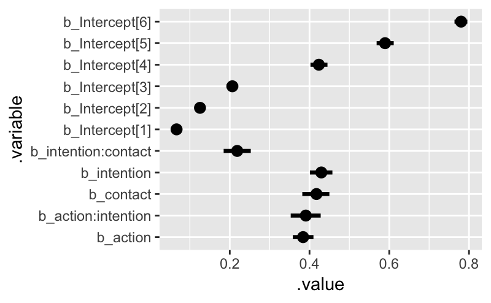

```r
gather_draws(b11.3, `b_.*`, regex = TRUE) %>%
  mutate(.value = inv_logit_scaled(.value)) %>%
  median_hdi() %>%
  ggplot(aes(x = .value, y = .variable)) +
    geom_pointintervalh()
```

[figure not shown]

# Ordered categorical predictors

We don’t want to treat ordered categorical variables as continuous because we want to assume different distances between such a variable’s values.

```r
education_levels <- c("Elementary School", "Middle School", "Some High School", "High School Graduate",
                      "Some College", "Bachelor's Degree", "Master's Degree", "Graduate Degree")
df$edu <- fct_relevel(df$edu, education_levels)
df$edu %>% summary
```

```
   Elementary School        Middle School     Some High School High School Graduate         Some College
                  60                  120                  420                  870                 2460
   Bachelor's Degree      Master's Degree      Graduate Degree
                3540                 1410                 1050
```

We would like to encode this variable such that each step up in education comes with its own incremental effect on the outcome (or linear model). Below, we look to model the survey response against the respondents education levels. $K$ represents the individual cutpoints, or intercepts, for our outcome variable. $\beta_E$ represents the impact of maximum education. $E_i$ is the completed education level for individual $i$.

$$response_i \sim OrderedLogit(\phi_i, K)
\\
\phi_i = \beta_E \sum_{j=0}^{E_i - 1} \delta_j + other\_stuff
\\
...priors...
\\\
\delta \sim Dirichlet(\alpha)$$
We let our $\delta$ parameters be *dirichlet* distributed. The Dirichlet distribution is a generalization of the beta distribution that returns a vector of probabilities that sum to one. In the Dirichlet, the only parameter is a long vector with pseudo-counts for each possibility. Below, we show an example with $\alpha = rep(2, 7)$.

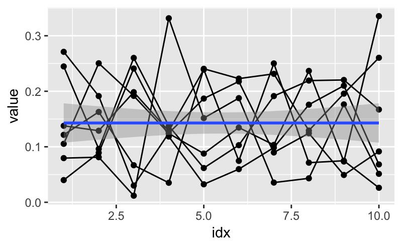

```r
library(gtools)
set.seed(1805)
as_tibble((rdirichlet( 10 , alpha=rep(2,7) ))) %>%
  mutate(idx = 1:10) %>%
  select(idx, everything()) %>%
  gather(draw, value, -idx) %>%
  ggplot(aes(x = idx, y = value, group = as.factor(draw))) +
    geom_point() +
    geom_line() +
    geom_smooth(inherit.aes = FALSE,
                aes(x = idx, y = value),
                method = "lm")
```

# Homework

## 11H1

```r
library(rethinking)
data(Hurricanes)
df <- as_data_frame(Hurricanes)
rm(Hurricanes)
detach("package:rethinking")
df
```

| name | year | deaths | category | min_pressure | damage_norm | female | femininity |
| --- | --- | --- | --- | --- | --- | --- | --- |
| Easy | 1950 | 2 | 3 | 960 | 1590 | 1 | 6.77778 |
| King | 1950 | 4 | 3 | 955 | 5350 | 0 | 1.38889 |
| Able | 1952 | 3 | 1 | 985 | 150 | 0 | 3.83333 |
| Barbara | 1953 | 1 | 1 | 987 | 58 | 1 | 9.83333 |
| Florence | 1953 | 0 | 1 | 985 | 15 | 1 | 8.33333 |
| Carol | 1954 | 60 | 3 | 960 | 19321 | 1 | 8.11111 |
| Edna | 1954 | 20 | 3 | 954 | 3230 | 1 | 8.55556 |
| Hazel | 1954 | 20 | 4 | 938 | 24260 | 1 | 9.44444 |
| Connie | 1955 | 0 | 3 | 962 | 2030 | 1 | 8.50000 |
| Diane | 1955 | 200 | 1 | 987 | 14730 | 1 | 9.88889 |

[output cut: 82 more lines]

```r
loo(fit.11h1.1, fit.11h1.2, reloo = TRUE)
```

[output not shown]

```
                          LOOIC      SE
fit.11h1.1              4440.27 1075.95
fit.11h1.2              4430.15 1014.14
fit.11h1.1 - fit.11h1.2   10.12  133.67
```

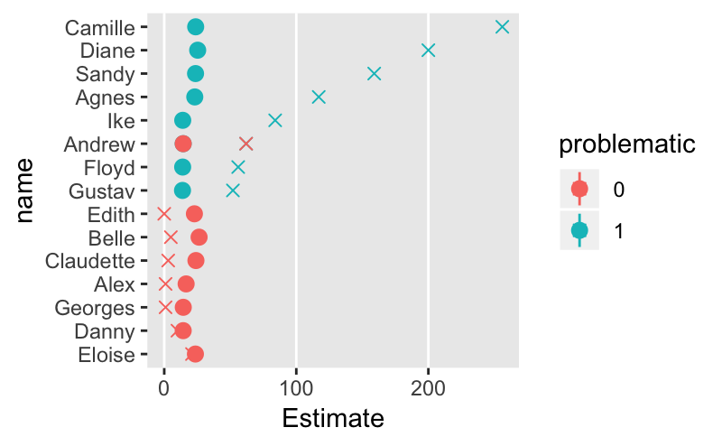

```r
fitted(fit.11h1.2, newdata = df) %>%
  as_data_frame %>%
  bind_cols(df) %>%
  slice(c(c(10, 29, 34, 59, 70, 88, 89, 92), sample(1:92, 8))) %>%
  mutate(row_num = row_number(),
         problematic = as.factor(c(rep(1, 8), rep(0, 8))),
         name = fct_reorder(name, abs(Estimate - deaths))) %>%
  ggplot(aes(x = name, y = Estimate,
             ymin = `Q2.5`, ymax = `Q97.5`,
             color = problematic)) +
    geom_pointrange() +
    geom_point(aes(y = deaths), shape = 4, size = 2) +
    coord_flip() +
    theme(panel.grid.major.y = element_blank(),
          panel.grid.minor.x = element_blank())
```

Fit a gamma-Poisson (aka negative-binomial) model to predict deaths using femininity

[output not shown]

```r
fit.11h2.1 <- brm(data = df, family = negbinomial,
         deaths ~ 1 + femininity,
         prior = c(prior(normal(0, .5), class = b)),
         iter = 4000, warmup = 1000, cores = 2, chains = 2)
```

```
starting worker pid=32818 on localhost:11036 at 19:05:26.642
starting worker pid=32828 on localhost:11036 at 19:05:26.885
```

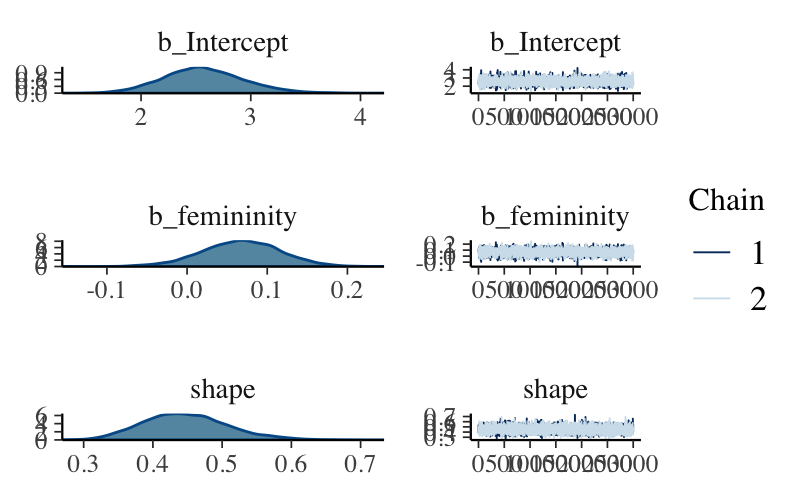

```r
plot(fit.11h2.1)
```

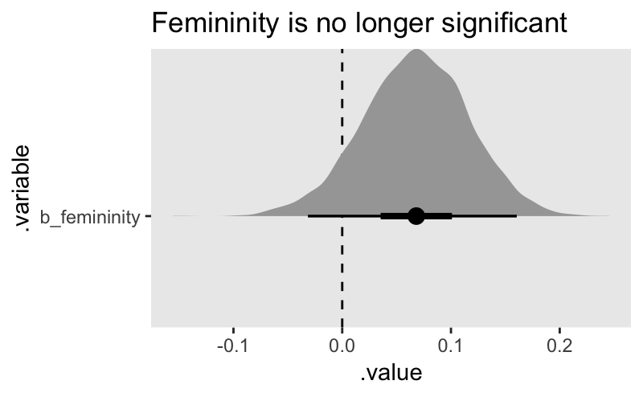

```r
gather_draws(fit.11h2.1, b_femininity) %>%
  ggplot(aes(.value, .variable)) +
    geom_vline(xintercept = 0, linetype = 2) +
    geom_halfeyeh(.width = c(.5, .95)) +
    theme(panel.grid = element_blank()) +
    ggtitle("Femininity is no longer significant")
```

```r
loo(fit.11h2.1, fit.11h1.2, reloo = TRUE)
```

[output not shown]

```
                           LOOIC      SE
fit.11h2.1                709.61   32.10
fit.11h1.2               4426.03 1011.40
fit.11h2.1 - fit.11h1.2 -3716.42  989.93
```

```r
fit.11h3.1 <- brm(data = df, family = negbinomial,
                  deaths ~ 1 + femininity + damage_norm,
         prior = c(prior(normal(0, .5), class = b)),
         iter = 4000, warmup = 1000, cores = 2, chains = 2)
```

```
recompiling to avoid crashing R session
```

```
starting worker pid=33863 on localhost:11036 at 19:19:42.245
starting worker pid=33873 on localhost:11036 at 19:19:42.496
```

[output not shown]

```r
fit.11h3.2 <- brm(data = df, family = negbinomial,
                  deaths ~ 1 + femininity + log(damage_norm),
         prior = c(prior(normal(0, .5), class = b)),
         iter = 4000, warmup = 1000, cores = 2, chains = 2)
```

```
recompiling to avoid crashing R session
```

```
starting worker pid=34070 on localhost:11036 at 19:22:17.729
starting worker pid=34080 on localhost:11036 at 19:22:17.962
```

```r
loo(fit.11h2.1, fit.11h3.1, fit.11h3.2)
```

```
                         LOOIC    SE
fit.11h2.1              709.61 32.10
fit.11h3.1              671.04 33.79
fit.11h3.2              630.32 31.14
fit.11h2.1 - fit.11h3.1  38.57 10.44
fit.11h2.1 - fit.11h3.2  79.29 10.92
fit.11h3.1 - fit.11h3.2  40.72 12.47
```

For our best performing model, femininity is not very important.

[figure not shown]

```r
gather_draws(fit.11h3.2, b_femininity) %>%
  median_hdci()
```

| .variable | .value | .lower | .upper | .width | .point | .interval |
| --- | --- | --- | --- | --- | --- | --- |
| b_femininity | 0.02309695 | -0.04588608 | 0.08806794 | 0.95 | median | hdci |

## 11H6

```r
library(tidyverse)
library(brms)
library(tidybayes)

library(rethinking)
data(Fish)
df <- as_data_frame(Fish)
rm(Fish)
detach("package:rethinking")
df
```

| fish_caught | livebait | camper | persons | child | hours |
| --- | --- | --- | --- | --- | --- |
| 0 | 0 | 0 | 1 | 0 | 21.124 |
| 0 | 1 | 1 | 1 | 0 | 5.732 |
| 0 | 1 | 0 | 1 | 0 | 1.323 |
| 0 | 1 | 1 | 2 | 1 | 0.548 |
| 1 | 1 | 0 | 1 | 0 | 1.695 |
| 0 | 1 | 1 | 4 | 2 | 0.493 |
| 0 | 1 | 0 | 3 | 1 | 0.033 |
| 0 | 1 | 0 | 4 | 3 | 0.004 |
| 0 | 0 | 1 | 3 | 2 | 0.217 |
| 1 | 1 | 1 | 1 | 0 | 4.031 |

[output cut: 240 more lines]

We want to model fish per person per hour so we’ll add an explicity denominator for our rate

```r
df$log_person_hours <- log(df$persons * df$hours)
```

Now lets fit the data with that offset.

```r
fit.11h6.1 <-
  brm(data = df, family = zero_inflated_poisson,
      bf(fish_caught ~ 1 + offset(log_person_hours) + livebait + child,
         zi ~ 1 + child),
      # Fishing rate
      prior = c(prior(normal(1, .5), class = Intercept),
      # Probability of drinking
      prior(normal(0, 1), class = b)),
      cores = 4, sample_prior = "yes")
```

```
starting worker pid=35968 on localhost:11891 at 20:10:59.326
starting worker pid=35978 on localhost:11891 at 20:10:59.548
starting worker pid=35988 on localhost:11891 at 20:10:59.767
starting worker pid=35998 on localhost:11891 at 20:10:59.990
```

```r
print(fit.11h6.1)
```

```
 Family: zero_inflated_poisson
  Links: mu = log; zi = logit
Formula: fish_caught ~ 1 + offset(log_person_hours) + livebait + child
         zi ~ 1 + child
   Data: df (Number of observations: 250)
Samples: 4 chains, each with iter = 2000; warmup = 1000; thin = 1;
         total post-warmup samples = 4000

Population-Level Effects:
             Estimate Est.Error l-95% CI u-95% CI Eff.Sample Rhat
Intercept       -2.59      0.23    -3.08    -2.16       3123 1.00
zi_Intercept    -1.17      0.27    -1.73    -0.66       4522 1.00
livebait         1.44      0.24     1.01     1.93       2963 1.00
child            0.60      0.09     0.42     0.77       2208 1.00
zi_child         0.43      0.46    -0.58     1.21       2027 1.00

Samples were drawn using sampling(NUTS). For each parameter, Eff.Sample
is a crude measure of effective sample size, and Rhat is the potential
scale reduction factor on split chains (at convergence, Rhat = 1).
```

```r
get_variables(fit.11h6.1)
```

```
 [1] "b_Intercept"    "b_zi_Intercept" "b_livebait"     "b_child"
 [5] "b_zi_child"     "prior_b"        "lp__"           "accept_stat__"
 [9] "stepsize__"     "treedepth__"    "n_leapfrog__"   "divergent__"
[13] "energy__"
```

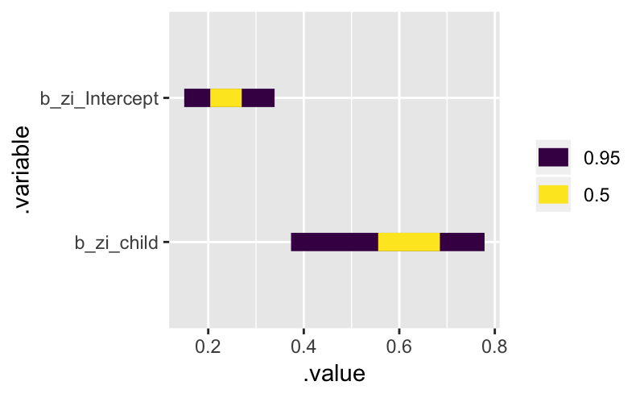

```r
gather_draws(fit.11h6.1, `b_zi_.*`, regex = TRUE) %>%
  mutate(.value = inv_logit_scaled(.value)) %>%
  median_hdi(.width = c(.5, .95)) %>%
  ggplot(aes(.value, .variable)) +
    geom_intervalh()
```

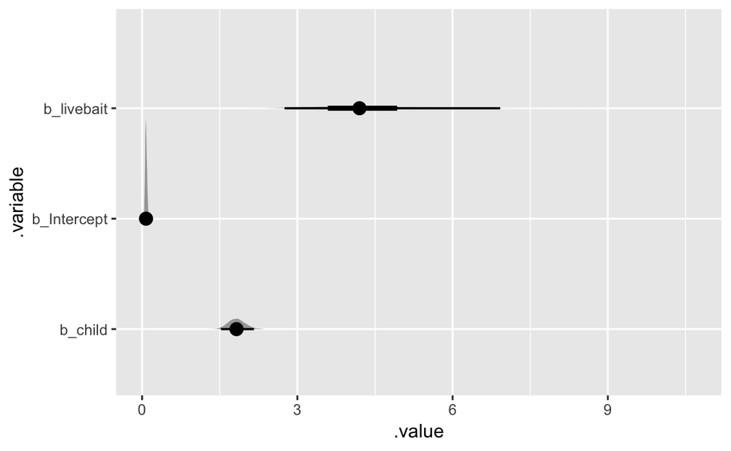

```r
gather_draws(fit.11h6.1, `b_[^z].*`, regex = TRUE) %>%
  mutate(.value = exp(.value)) %>%
  ggplot(aes(.value, .variable)) +
    geom_halfeyeh(.width = c(.5, .95))
```

```r
fixef(fit.11h6.1)
```

```
               Estimate  Est.Error       Q2.5      Q97.5
Intercept    -2.5854144 0.23444933 -3.0750894 -2.1613813
zi_Intercept -1.1661240 0.27277703 -1.7282040 -0.6604961
livebait      1.4422000 0.23648652  1.0127504  1.9343223
child         0.5995177 0.08881712  0.4211921  0.7701226
zi_child      0.4332892 0.45591294 -0.5789788  1.2105355
```

[output not shown]

[output cut: 240 more lines]

```r
l <- loo(fit.11h6.1,save_psis = TRUE, reloo = TRUE)
```

```
5 problematic observation(s) found.
The model will be refit 5 times.

Fitting model 1 out of 5 (leaving out observation 89)

Fitting model 2 out of 5 (leaving out observation 130)

Fitting model 3 out of 5 (leaving out observation 138)

Fitting model 4 out of 5 (leaving out observation 160)

Fitting model 5 out of 5 (leaving out observation 227)
```

```r
l
```

```
Computed from 4000 by 250 log-likelihood matrix
```

|  | Estimate | SE |
| --- | --- | --- |
| elpd_loo | -1082.1 | 194.5 |
| p_loo | 66.4 | 21.3 |
| looic | 2164.2 | 389.0 |

```
------
Monte Carlo SE of elpd_loo is NA.

Pareto k diagnostic values:
                         Count Pct.    Min. n_eff
(-Inf, 0.5]   (good)     247   98.8%   3
 (0.5, 0.7]   (ok)         3    1.2%   1048
   (0.7, 1]   (bad)        0    0.0%   <NA>
   (1, Inf)   (very bad)   0    0.0%   <NA>

All Pareto k estimates are ok (k < 0.7).
See help('pareto-k-diagnostic') for details.
```